# Prequsite_Manan

```python
import numpy as np
import pandas as pd
```

Q.1 How many multiplications and additions do you need to perform a matrix multiplication between a (n, k) and (k, m) matrix? Explain.

we have a matrix1 of size(n,k) and matrix2 (k,m) then the resulting matrix will have m*n elements and we need to do kmn additions and mulitplications.n

```python
Q.9 Using matplotlib plot the following functions on the domain: x = 0.5 to 100.0 in steps of 0.5.
```

```python
import matplotlib.pyplot as plt
```

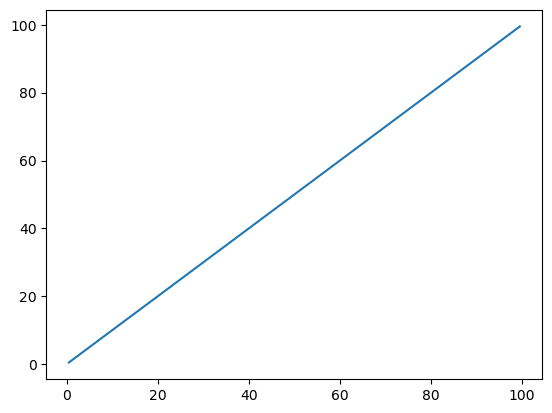

```python
x = (np.arange(0.5,100,0.5))
# x = x/2
y=x
plt.plot(x,y)
plt.show()
```

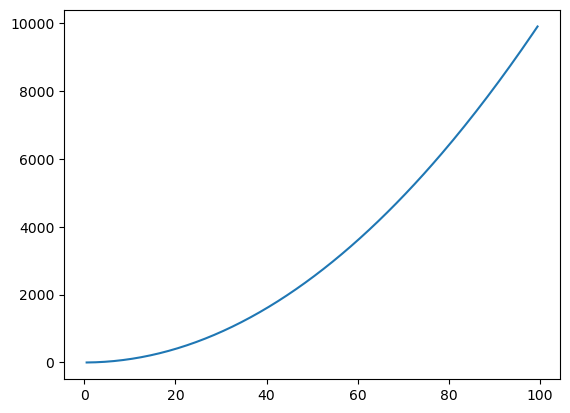

```python
y=x*x
plt.plot(x,y)
plt.show()
```

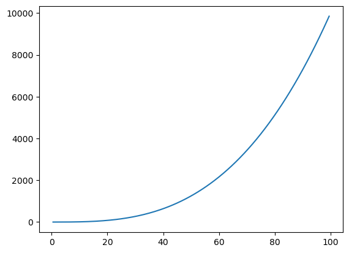

```python
y=x**3/100
plt.plot(x,y)
plt.show()
```

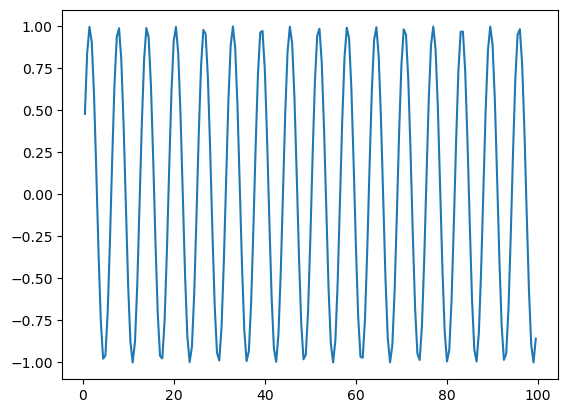

```python
y=np.sin(x)
plt.plot(x,y)
plt.show()
```

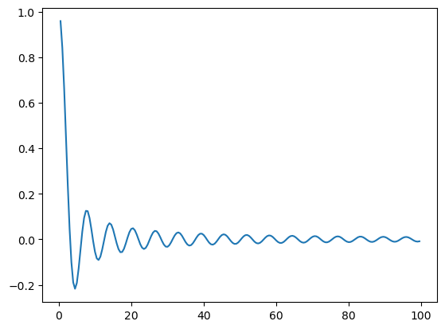

```python
y=np.sin(x)/x
plt.plot(x,y)
plt.show()
```

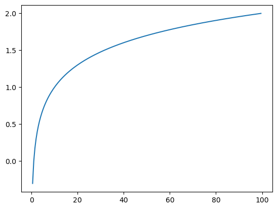

```python
plt.plot(x,np.log10(x))
plt.show()
```

y=np.exp(x) plt.plot(x,y) plt.show()

```python
Q.12 Write a small piece of code to explain broadcasting in numpy.
```

```python
matrix1 = np.random.randint(5,6,size=(1,5))
matrix2 = np.random.randint(10,11,size=(5,5))
print(matrix1)
print(matrix2)
print(matrix1+matrix2)
```

```
[[5 5 5 5 5]]
[[10 10 10 10 10]
 [10 10 10 10 10]
 [10 10 10 10 10]
 [10 10 10 10 10]
 [10 10 10 10 10]]
[[15 15 15 15 15]
 [15 15 15 15 15]
 [15 15 15 15 15]
 [15 15 15 15 15]
 [15 15 15 15 15]]
```

Q.13 Write a function to compute the argmin of a numpy array. The function should take a numpy array as input and return the index of the minimum element. You can use the np.argmin function to verify your solution.

```python
arr = np.random.randint(0,10,6)
def mini(ls):
    m=np.inf
    a=0
    for i in range(len(ls)):
        if ls[i]<m:
            m=ls[i]
            a=i
    return a
print(arr)
print(mini(arr))
print(np.argmin(arr))
```

```
[9 1 9 2 6 6]
1
1
```

```python
matrix = np.random.uniform(1,2,size=(20,5))
matrix
```

```
array([[1.64661236, 1.66946949, 1.95041276, 1.35460235, 1.54359487],
       [1.57587348, 1.58787367, 1.5859303 , 1.28964759, 1.01181021],
       [1.02662381, 1.7681458 , 1.57757431, 1.20847618, 1.98907551],
       [1.02593761, 1.71598752, 1.54772015, 1.32174162, 1.5428124 ],
       [1.52614549, 1.47654941, 1.31757419, 1.0566721 , 1.53825811],
       [1.27799793, 1.16532279, 1.70925434, 1.68455629, 1.64623564],
       [1.31249136, 1.40734028, 1.26189078, 1.89843628, 1.94655502],
       [1.82310422, 1.91848182, 1.05783401, 1.98023485, 1.00723112],
       [1.51302684, 1.41475215, 1.59837778, 1.50275085, 1.61487808],
       [1.25778981, 1.08847234, 1.69536008, 1.66124673, 1.87921352],
       [1.10319606, 1.92157626, 1.61542629, 1.74401998, 1.16024539],
       [1.0911635 , 1.42471928, 1.98978462, 1.22714077, 1.87259642],
       [1.32992591, 1.58475784, 1.52437874, 1.55145184, 1.17151031],
       [1.36646444, 1.46819685, 1.70847825, 1.63864455, 1.22916725],
       [1.24069499, 1.16014637, 1.93097902, 1.59170649, 1.34732123],
       [1.99966838, 1.76795003, 1.34119661, 1.53602833, 1.50048765],
       [1.76724877, 1.73209424, 1.69022134, 1.26962816, 1.70877693],
       [1.42903004, 1.17648469, 1.0894358 , 1.81550422, 1.55199912],
       [1.49964632, 1.76333613, 1.30295307, 1.98826912, 1.99130452],
       [1.95766976, 1.27924163, 1.09334545, 1.66777264, 1.9845967 ]])
```

Q.6 Use sympy to confirm that you obtain the same gradient analytically.

```python
from sympy import symbols, diff, sin

a, b = symbols('a b')


print(a, b)


function = ((a**2) * b) + ((b**3) * sin(a))


diff_a = diff(function, a)
diff_b = diff(function, b)


values = {a: 3, b: 6}


d_a = diff_a.subs(values)
d_b = diff_b.subs(values)


print(float(d_a))
print(float(d_b))
```

```
a b
-177.83837926569623
24.24096087046566
```

Q.7 Create a Python nested dictionary to represent hierarchical information. We want to store record of students and their marks. Something like:

```python
# Creating the nested dictionary directly
university = {
    '2021': {
        'Computer Science': [
            {'Roll Number': 101, 'Name': 'Alice', 'Scores': {'Math': 90, 'Physics': 85}},
            {'Roll Number': 102, 'Name': 'Bob', 'Scores': {'Math': 80, 'Physics': 88}}
        ],
        'Mechanical': [
            {'Roll Number': 103, 'Name': 'Charlie', 'Scores': {'Math': 75, 'Physics': 80}}
        ]
    },
    '2022': {
        'Electrical': [
            {'Roll Number': 104, 'Name': 'David', 'Scores': {'Math': 85, 'Physics': 87}},
            {'Roll Number': 105, 'Name': 'Eve', 'Scores': {'Math': 78, 'Physics': 82}}
        ],
        'Civil': [
            {'Roll Number': 106, 'Name': 'Frank', 'Scores': {'Math': 82, 'Physics': 79}}
        ]
    },
    '2023': {
        'Computer Science': [
            {'Roll Number': 107, 'Name': 'Grace', 'Scores': {'Math': 89, 'Physics': 84}},
            {'Roll Number': 108, 'Name': 'Hank', 'Scores': {'Math': 81, 'Physics': 86}}
        ],
        'Mechanical': [
            {'Roll Number': 109, 'Name': 'Ivy', 'Scores': {'Math': 76, 'Physics': 83}},
            {'Roll Number': 110, 'Name': 'Jack', 'Scores': {'Math': 74, 'Physics': 80}}
        ]
    }
}

# Printing the university data
for year, departments in university.items():
    print(f"Year: {year}")
    for department, students in departments.items():
        print(f"  Department: {department}")
        for student in students:
            print(f"    Roll Number: {student['Roll Number']}, Name: {student['Name']}, Scores: {student['Scores']}")
```

[output not shown]

Q.5 Use JAX to confirm the gradient evaluated by your method matches the analytical solution corresponding to a few random values of x and y

```python
pip install jax
```

```python
import jax.numpy as jnp
from jax import grad
```

```python
def sum_logistic(x,y):
  return ((x**2)*y) + ((y**3)*jnp.sin(x))
x=3.0
y=6.0
derivative_fn_x = grad(sum_logistic,argnums=0)
derivative_fn_y = grad(sum_logistic,argnums=1)
print(derivative_fn_x(x,y))
print(derivative_fn_y(x,y))
```

```
-177.83838
24.24096
```